# transit_ps6

Annie Gao

```r
func_abs_related <- read_csv("/project2/ppha30531/axgao1/func_abs_related.csv")
hrs <- read_csv("/project2/ppha30531/axgao1/hrs.csv")
ot_fund <- read_csv("/project2/ppha30531/axgao1/ot_fund.csv")
timekeep <- read_csv("/project2/ppha30531/axgao1/timekeep.csv")
weather <- readxl::read_excel("/project2/ppha30531/axgao1/Weather Events Hol.xlsx")
```

# Problem Set 5 Solutions

# PROBLEM SET 6 BEGINNING

# 3 STA Insufficient headcount

## 1

```r
abs_ot_funcdescr <- inner_join(ot_fund, func_abs_related,
                               by = c("Payroll.Function.Description")) %>%
  select(Fiscal.Year,
         Absence.Non.Absence,
         Payroll.RollUp.Department.Description,
         Payroll.Job.Title,
         Payroll.Function.Description,
         Payroll.Hours,
         Overtime.Amount,
         Employee.ID)

abs_ot_funcdescr %>%
  filter(Fiscal.Year == 2016 & Absence.Non.Absence == "Absence Related") %>%
  group_by(Payroll.RollUp.Department.Description) %>%
  summarise(total_dollars = sum(Overtime.Amount)) %>%
  arrange(desc(total_dollars)) %>%
  head(5)
```

```
## # A tibble: 5 x 2
##   Payroll.RollUp.Department.Description total_dollars
##   <chr>                                         <dbl>
## 1 BusTrans                                    6675241
## 2 Heavy Rail                                  2553776
## 3 BusMaint                                    1787006
## 4 Rail Mntnc                                  1272838
## 5 Light Rail                                   921687
```

The departments billing the most absence-related overtime overall in dollar terms are BusTrans, Heavy Rail, BusMaint, Rail Mntnc, and Light Rail.

## 2

```r
ot_dept_abs <- inner_join(hrs, abs_ot_funcdescr, by = c("Employee.ID", "Payroll.Job.Title"))

ot_dept_abs %>%
  group_by(Payroll.RollUp.Department.Description, Absence.Non.Absence) %>%
  summarise(ot_hrs = sum(Payroll.Hours.x, na.rm = TRUE)) %>%
  mutate(prop_abs_OT = ot_hrs/sum(ot_hrs)) %>%
  arrange(desc(prop_abs_OT)) %>%
  head(3)
```

```
## # A tibble: 3 x 4
## # Groups:   Payroll.RollUp.Department.Description [3]
##   Payroll.RollUp.Department.Descri… Absence.Non.Absen…  ot_hrs prop_abs_OT
##   <chr>                             <chr>                <dbl>       <dbl>
## 1 AFC 1.0                           Non-Absence Relat…  2.35e⁴        1.00
## 2 Cnstr Mgmt                        Non-Absence Relat…  4.25e⁷        1.00
## 3 Constr E&M                        Non-Absence Relat…  4.99e⁶        1.00
```

# 4 STA Shenanigans

## 1

```r
mean(employee_weeks$logical)
```

```
## [1] 0.288
```

The share of employee-weeks with an absence is 28.8 percent. This estimate is extremely high since external benchmarks show absence rates to be below 5%.

## 2

```r
#build double dip binary indicator
employee_weeks$all_ot <- employee_weeks$hrs_built_in_ot +
  employee_weeks$hrs_ot_15 +
  employee_weeks$hrs_ot_20 +
  employee_weeks$diff_pay +
  employee_weeks$hrs_reg_pay

employee_weeks$dbldip <- ifelse(employee_weeks$logical == 1 &
                                  employee_weeks$all_ot > 0, 1, 0)

#setup to filter on year
employee_weeks$year <- year(employee_weeks$week)

employee_weeks %>%
  filter(year == 2015) %>%
  group_by(Employee.ID) %>%
  summarise(weeks_worked = n(), total_dbldip_emp = sum(dbldip)) %>% #weeks_worked measures how many times each employee showed by row = number of weeks worked
  filter(weeks_worked >= 26) %>%
  mutate(share_weeks_dbldip = total_dbldip_emp/weeks_worked) %>%
  arrange(desc(share_weeks_dbldip)) %>%
  head(5)
```

```
## # A tibble: 5 x 4
##   Employee.ID weeks_worked total_dbldip_emp share_weeks_dbldip
##         <int>        <int>            <dbl>              <dbl>
## 1        8990           48             48.0               1.00
## 2        9743           51             51.0               1.00
## 3       14578           34             34.0               1.00
## 4       15440           50             50.0               1.00
## 5       15747           50             50.0               1.00
```

The top 5 employees with the highest share of weeks double-dipping are Employee 8990, 9743, 14578, 15440, and 15747. They all have 100% double dipping rates. For all the 26 weeks or more that they worked, they doubled dipped in every week they worked.

# 5 STA Snow

## 1

```r
snow_storm <- weather %>%
  mutate(sum = PRECIPITATION + lag(PRECIPITATION)) %>%
  filter(TYPE == "S") %>%
  arrange(desc(sum)) %>%
  head(3)

snow_storm$name <- c("Storm1", "Storm2", "Storm3")
```

Using lag, the three biggest snowstorm dates as the first date are 2011-02-26, 2011-01-12, and 2013-02-09. The precipitation from these dates are sums of the previous date and the date shown for a full 48 hour span. For 2011-02-26, it seems that the day after (the 27th) had the largest accumulation.

## 2

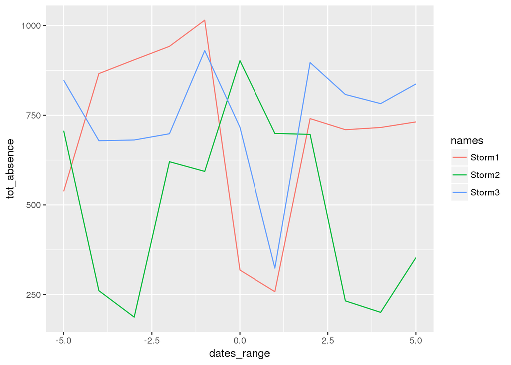

```r
#get all absences on each day and then filter out dates of interest and create range around them
snow_absence <- timekeep %>%
  group_by(Calendar.Full.Date) %>%
  summarise(tot_absence = sum(Total...of.Days)) %>%
  filter(between(Calendar.Full.Date, as.Date("2011-02-26") - days(5),
                 as.Date("2011-02-26") + days(5)) |
          between(Calendar.Full.Date, as.Date("2011-01-12") - days(5),
                  as.Date("2011-01-12") + days(5)) |
          between(Calendar.Full.Date, as.Date("2013-02-09") - days(5),
                  as.Date("2013-02-09") + days(5)))

#first name ranges by date of storm
snow_absence <- snow_absence %>%
  mutate(storm_dates = ifelse(between(Calendar.Full.Date, as.Date("2011-02-26") - days(5),
                                as.Date("2011-02-26") + days(5)), "2011-02-26",
                              ifelse(between(Calendar.Full.Date, as.Date("2011-01-12") - days(5),
                                as.Date("2011-01-12") + days(5)), "2011-01-12", "2013-02-09")))

#then name storms for group/color for plotting
snow_absence$names <- ifelse(snow_absence$storm_dates == "2011-02-26", "Storm1",
                             ifelse(snow_absence$storm_dates == "2011-01-12", "Storm2",
                                    "Storm3"))

#create range for plotting x axis
snow_absence <- snow_absence %>%
  mutate(dates_range = Calendar.Full.Date - as.Date(storm_dates))

#plot
ggplot(snow_absence, aes(x = dates_range, y = tot_absence)) +
  geom_line(aes(group = names, color = names))
```

## 3

```r
#from original weather df, find total precipitation for each possible week
#that 3 storms coud have occurred
weather_storm_weeks <- weather %>%
  mutate(poss_week = floor_date(OBSERVATION_DATE, unit = "week")) %>%
  group_by(poss_week) %>%
  summarise(tot_precip = sum(PRECIPITATION, na.rm = TRUE))

#create vector of week the 3 storms occurred on
storm_weeks_vec <- c(floor_date(as.Date("2011-02-26"), "week"),
                     floor_date(as.Date("2011-01-12"), "week"),
                     floor_date(as.Date("2013-02-09"), "week"))

#create indicator for whether storm occurred in that week
weather_storm_weeks <- weather_storm_weeks %>%
  mutate(week_w_storm = ifelse(as.Date(poss_week) %in% storm_weeks_vec, 1, 0))

#get months of all weeks and filter out Jan without precipitation
#or week storm occurred
weather_storm_weeks <- weather_storm_weeks %>%
  mutate(month = month(poss_week)) %>%
  filter((month == 1  & tot_precip == 0) | week_w_storm == 1) %>%
  mutate(storm_week = as.Date(poss_week))

#find weeks in otfund that are same weeks of storms and join two dfs
ot_fund_weeks <- ot_fund %>%
  mutate(weeks = floor_date(Payroll.End.Date, unit = "week"))

storm_weeks_ot <- left_join(weather_storm_weeks, ot_fund_weeks,
                            by = c("storm_week" = "weeks"))

storm_weeks_ot %>%
  group_by(storm_week, week_w_storm) %>%
  summarise(tot_ot_amt = sum(Overtime.Amount))
```

```
## # A tibble: 4 x 3
## # Groups:   storm_week [?]
##   storm_week week_w_storm tot_ot_amt
##   <date>            <dbl>      <dbl>
## 1 2011-01-09         1.00         NA
## 2 2011-02-20         1.00         NA
## 3 2012-01-29         0        908370
## 4 2013-02-03         1.00    1233006
```

Overtime costs in weeks of snowstorm are $1233006 for the week of 2013-02-03.

## 4

```r
#days of storm
#2011-02-26
#2011-01-12
#2013-02-09

#above
storm_weeks_vec <- c(floor_date(as.Date("2011-02-26"), "week"),
                     floor_date(as.Date("2011-01-12"), "week"),
                     floor_date(as.Date("2013-02-09"), "week"))

#convert weeks to dates in week and merge vector in employee_weeks
days_vec1 <- seq(as.Date("2011-02-20"), as.Date("2011-02-27"), by = "days")
days_vec2 <- seq(as.Date("2011-01-09"), as.Date("2011-01-16"), by = "days")
days_vec3 <- seq(as.Date("2013-02-03"), as.Date("2013-02-10"), by = "days")
days_vec <- as.vector(rbind(days_vec1, days_vec2, days_vec3))

#convert weeks to poss_weeks to match storm weeks
employee_weeks$poss_weeks <- floor_date(employee_weeks$week, "week")

#creates new df where all employee info pertain to storm weeks
employee_weeks_storm <- employee_weeks %>%
  group_by(poss_weeks) %>%
  mutate(week_indicator = ifelse(poss_weeks %in% days_vec, 1, 0)) %>%
  filter(week_indicator == 1)

#group_by
employee_weeks_storm %>%
  group_by(poss_weeks) %>%
  mutate(all_dates = days(between(poss_weeks, as.Date("2011-02-20"), as.Date("2011-02-27"))))
```

```
## # A tibble: 9,971 x 18
## # Groups:   poss_weeks [2]
##    week       Employee.ID hrs_built_in_ot hrs_ot_15 hrs_ot_20 diff_pay
##    <date>           <int>           <dbl>     <dbl>     <dbl>    <dbl>
##  1 2013-02-04         337           0.200      0            0        0
##  2 2013-02-04         352           0          0            0        0
##  3 2013-02-04         366           0          8.00         0        0
##  4 2013-02-04         585           0          8.00         0        0
##  5 2013-02-04        1008           0         15.0          0        0
##  6 2013-02-04        1009           0         16.5          0        0
##  7 2013-02-04        1015           0         21.3          0        0
##  8 2013-02-04        1016           0         27.2          0        0
##  9 2013-02-04        1032           0          0            0        0
## 10 2013-02-04        1042           0          0            0        0
## # ... with 9,961 more rows, and 12 more variables: hrs_reg_pay <dbl>,
## #   Hourly.Rate <dbl>, Unscheduled <dbl>, Scheduled <dbl>,
## #   Total.Absences <dbl>, logical <dbl>, all_ot <dbl>, dbldip <dbl>,
## #   year <dbl>, poss_weeks <date>, week_indicator <dbl>, all_dates <dbl>
```

```r
#multiply hrs by 1.5
employee_weeks_storm$storm_cost <- employee_weeks_storm$Hourly.Rate * 1.5

#this would make more sense if I could change weeks to dates in employee_weeks
#and then filter the dates that match storm dates and then group by storm dates
employee_weeks_storm %>%
  group_by(poss_weeks)
```

```
## # A tibble: 9,971 x 18
## # Groups:   poss_weeks [2]
##    week       Employee.ID hrs_built_in_ot hrs_ot_15 hrs_ot_20 diff_pay
##    <date>           <int>           <dbl>     <dbl>     <dbl>    <dbl>
##  1 2013-02-04         337           0.200      0            0        0
##  2 2013-02-04         352           0          0            0        0
##  3 2013-02-04         366           0          8.00         0        0
##  4 2013-02-04         585           0          8.00         0        0
##  5 2013-02-04        1008           0         15.0          0        0
##  6 2013-02-04        1009           0         16.5          0        0
##  7 2013-02-04        1015           0         21.3          0        0
##  8 2013-02-04        1016           0         27.2          0        0
##  9 2013-02-04        1032           0          0            0        0
## 10 2013-02-04        1042           0          0            0        0
## # ... with 9,961 more rows, and 12 more variables: hrs_reg_pay <dbl>,
## #   Hourly.Rate <dbl>, Unscheduled <dbl>, Scheduled <dbl>,
## #   Total.Absences <dbl>, logical <dbl>, all_ot <dbl>, dbldip <dbl>,
## #   year <dbl>, poss_weeks <date>, week_indicator <dbl>, storm_cost <dbl>
```